# BuzzFeed Quizzes

Lilian Nguyen

# Buzzfeed Quizzes

## Overview

Quizzes are a pinacle aspect of the wildly sucessful online website, “BuzzFeed.” As a result, I decided to explore some characteristics of these quizzes, such as the gender of the writer and the number of questions in each quiz. This was done by examining the 75 most recent Buzzfeed quizzes and recording a variety of characteristics regarding the quizzes. The research question is what qualities are common among the popular Buzzfeed quizzes.

## Exploratory Analysis

Due to the number of “views” for a quiz being unaccessible, I decided to use the number of comments to indicate the popularity of a quiz. The graph below demonstrates which classification of quizzes is most popular for the quiz-takers.

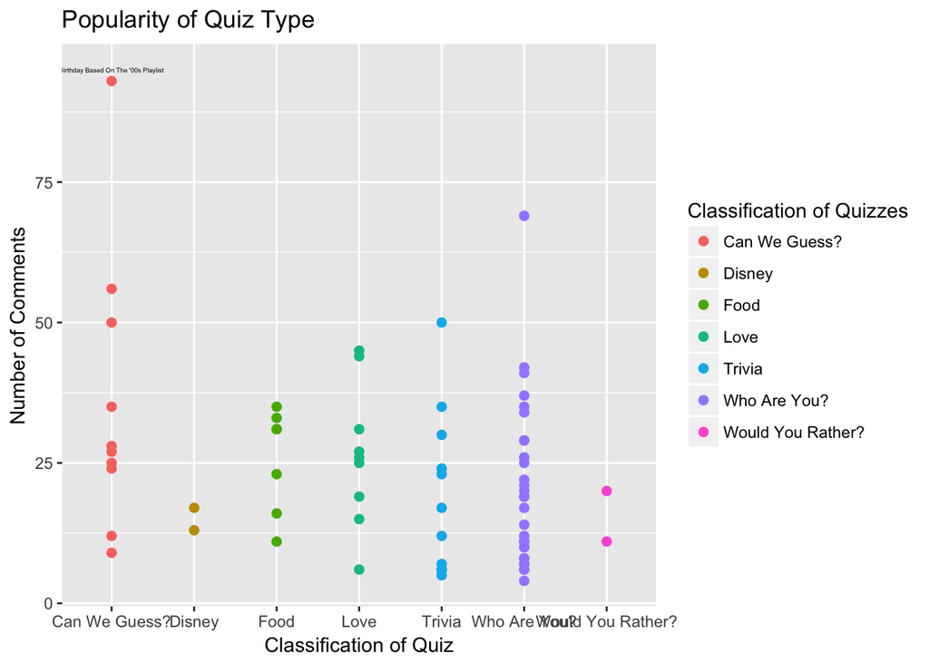

Interestingly, the category “Can We Guess?” is the category that the most popular quiz belonged to. The second quiz with the most comments was found in the classification, “Who Are You?”. Therefore, I decided to examine these two categories more closely.

However, it is important to note that there is no significantly correlation between classification of the quiz and the number of comments left.

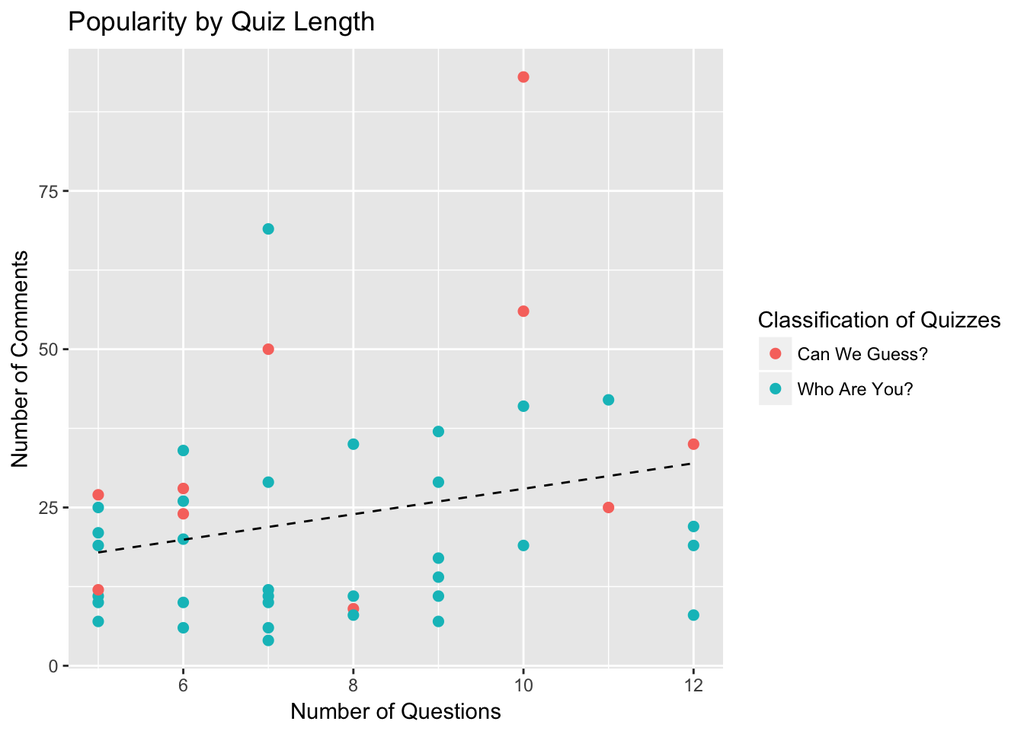

Despite the narrowing of the dataset, there is still no correlation to be seen. Therefore, I decided to examine if quiz topic could be used to estimate the popularity of the quizzes.

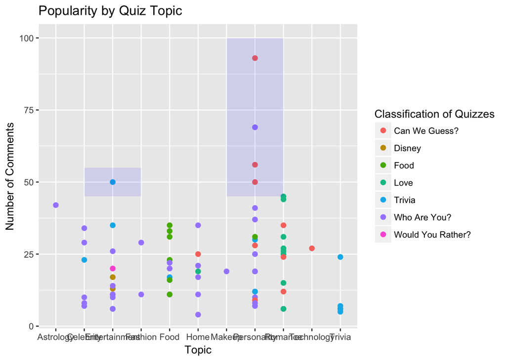

The top 5, most popular quizzes are highlighted. It appears that the most popular quizzes were those that dealt with the topic of “Personality.” As one can see, this topic contains various classifications that were provided by BuzzFeed. However, there appears to be no correlation between the topic and its popularity, as some quizzes in the “Personality” topic have few comments.

As my classification of the different quizzes was more specific than the BuzzFeed’s classification, I decided to use my own classification for the remainder of this study.

Next, I decided to examine the number of questions to the popularity of the quiz. Of those recorded, Buzzfeed quizzes have a minimum of 5 questions. I wanted to see if the number of questions correlated to its popularity.

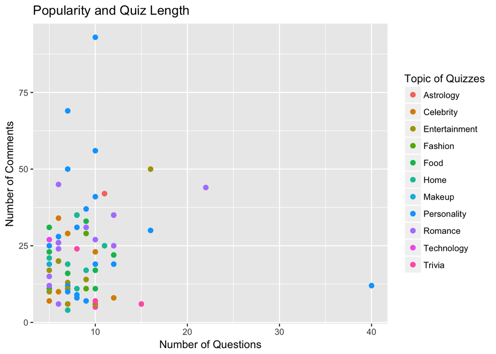

As demonstrated by the graph above, there appears to be no significant correlation between the number of questions and the number of comments. Therefore, I concluded that there is no correlation between number of questions per quiz and its popularity.

With no concrete correlation between the popularity of the quizzes and another variable, I wanted to see if a correlation between the gender of the quiz writer and the popularity of the quiz exist.

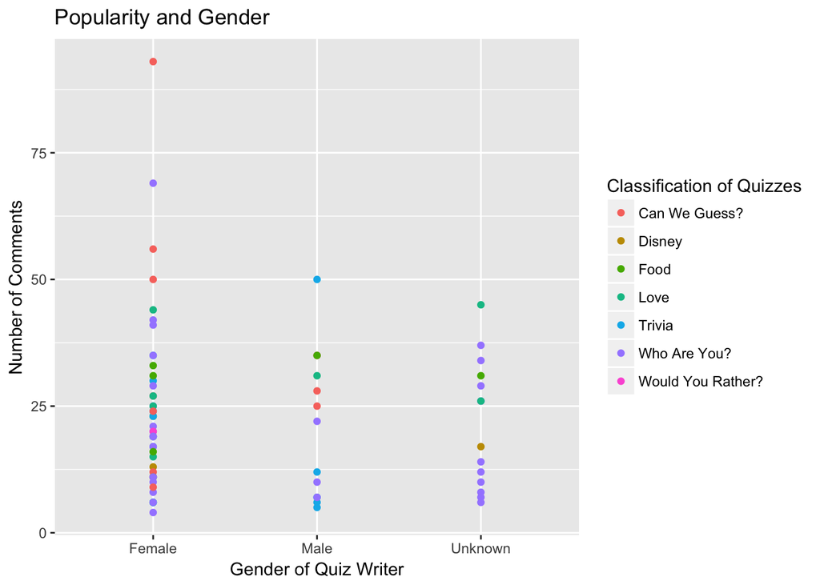

As seen above, most of the quizzes were written by females. It is also evident that the most popular quizzes were written by females.

## Conclusion

From the data above, it appears that there is there is no real correlation between any of the qualities explored and its popularity. However, due to the amount of views being unavailable, it is possible that the use of “number of comments” to measure popularity is inaccurate. If this study was done again, I would attempt to find the number of views for each quiz.

The lack of a significant correlation was not too surprising. BuzzFeed, a company known for its erraticism, constantly releases hundreds of quizzes daily, covering varying topics. Therefore, its secret to success may not be discerned.

## References

Buzzfeed, web. Accessed 9 Feb. 2018. (https://www.buzzfeed.com)